# Data Analyst Job Postings

Salary, Experience, and Data Languages

May 24, 2026

## Overview

This report summarizes a sample of **400** Data Analyst job postings scraped from online listings. Each record includes an estimated median salary, a minimum years-of-experience requirement (when extractable from the posting text), and a categorical label for whether the role mentions **R**, **Python**, **both**, or **neither** as data languages.

The analytic sample is limited: **89** postings (22.2%) could not be assigned a numeric minimum experience (including literal `"NA"` or failed extraction). For the scatter plot, **311** postings have both a numeric experience value and a salary estimate. Language categories are uneven—**Neither** dominates—so comparisons across groups should be read cautiously.

## Experience and salary

Minimum experience requirements are not always stated clearly in postings; values were extracted automatically and may be incomplete or approximate. The scatter plot below relates **minimum years of experience** to **median salary estimate** for postings with numeric experience only.

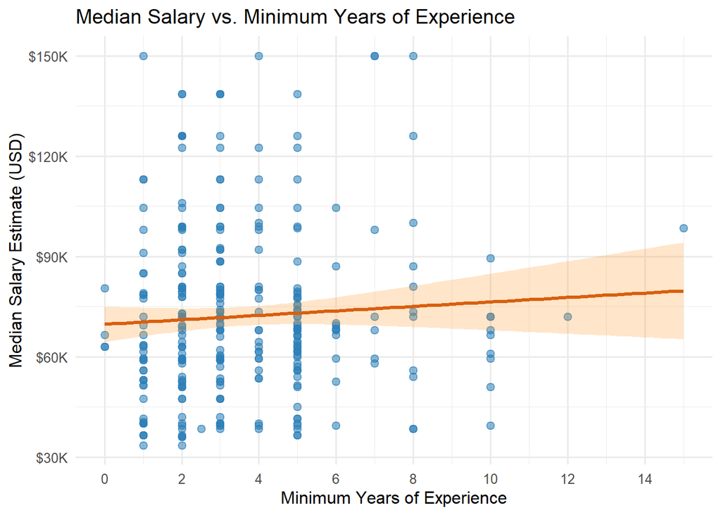

**Interpretation.** Among the 311 postings with usable experience data, salaries span roughly **$33,500** to **$150,000**, with minimum experience ranging from **0** to **15** years. The fitted trend line suggests how salary co-varies with stated experience in this sample; it is descriptive, not causal—location, industry, seniority wording, and company size are not controlled here.

**Limitations.** With only **311** complete cases (and **400** listings overall), a few high- or low-salary outliers can strongly influence the regression line. Missing or mis-parsed experience (89 rows) may differ systematically from postings with clear requirements, which introduces selection bias. Treat any apparent slope as exploratory rather than predictive.

## Salary by data language

The box plot compares **median salary estimate** across four language categories: R, Python, both, or neither mentioned in the posting.

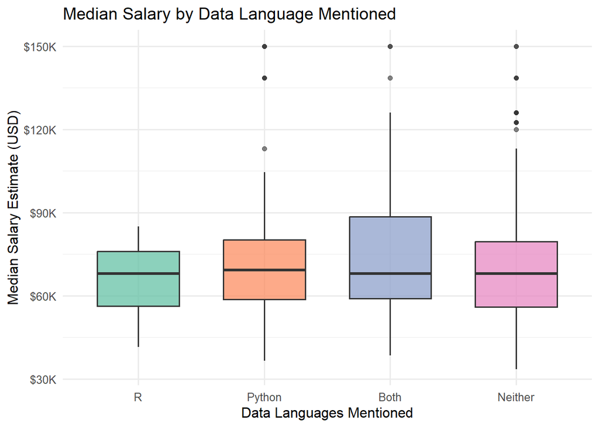

**Interpretation.** Median salaries and spreads differ across language groups, but group sizes are imbalanced: **256** postings mention neither R nor Python, compared with **60** for Python, **69** for both, and **15** for R alone. Boxes for smaller groups (especially **R**) are driven by few observations, so whiskers and medians are unstable.